# MolB-RTI vs Skim-RTI vs BrB-RTI — 3-way ancestry comparison (pedigree-matched, calibrated r)

Author

Fausto Rodríguez-Zapata

Published

June 24, 2026

**Repo:** sawers-rellan-labs/zealtiger

Three ancestry sources on the BZea NILs, each called at **its own truth-derived rigidity**: **MolB-RTI** (MolBreeding target-capture, ~110×, r=2), **Skim-RTI** (SNP50K skim, ~0.4×, r=5), and **BrB-RTI** (BRB-seq 3′ bulk RNA-seq, **wideseq-filtered, KS-calibrated r=7**). Calls are RTIGER segments on B73 NAM v5 (`name, chr, start_bp, end_bp, state`; 0 = recurrent/B73, 1 = het, 2 = homozygous donor). The **Null** is the n=1500 BC2S3 simulation (consensus map, no selection) — a modeled expectation, not ground truth; the neutral breeding-scheme single-locus expectation is **p0**.

**Why this notebook supersedes `molbreeding_vs_skim_calibrated`.** Two corrections:

1. **BrB-RTI = wideseq-filtered, r=7.** On the full BRB SNP set the dense, noisy 3′ markers forced an extreme rigidity (r=109). Restricting the BRB allele counts to the **wideseq teosinte-informative positions** (21,665 sites) strips the off-target noise and drops the KS-calibrated rigidity to **r=7** (D=0.103 vs 0.112; see `skim_vs_brbseq`) — the Skim-RTI regime, far finer resolution. The B73 control is a clean rep (`PN3_SID213`); the old `PN1_SID15` was an introgressed impostor (`docs/b73_checks_qc.html`). BrB-RTI is fit **per teosinte species** (emissions estimated within each species partition, B73/Purple as separate checks; `results/sim_calibration/brbseq_taxa_r109/`), and the 4 NIL calls are subset from that fit — a single EM pooled across species mis-specifies the emission regime and destabilises the B73 control (it read 0.41 donor in a mixed cohort, 0.13 per-species).
2. **BRB↔︎MolB is matched by pedigree, not by `PN#_SID#` prefix.** The prefix is **per-experiment**: Skim and MolBreeding share one id space, but **BRB-seq has its own**. The frozen notebook’s `intersect(brb$name, mb$name)` therefore compared *incomparable* samples (8 unrelated PN4 BRB libraries). The true cross-experiment key is the **pedigree** (`.B`-dropped); curated in `sample_correspondence.qmd`. Only **4 of the 14 MolB NILs** were also sequenced in BRB-seq.

**The BrB lane in the painting.** MolB-RTI and Skim-RTI cover all 16 MolB samples (14 NILs + 2 B73-bulk checks). BrB-RTI covers:

- the **4 pedigree-matched NILs** (real BRB partner, relabelled to the MolB id);
- the **2 B73 checks** → **blank** BrB lane. (B73 is monomorphic recurrent and the BRB checks have no pedigree, so a cross-experiment B73 id cannot be confirmed. A putative best-hit B73 fill is held back pending a physical-sample key from Hannah — `sample_correspondence.qmd`, “Checks to resolve”.)
- the remaining **10 NILs have no BRB counterpart** → **blank** BrB lane.

Quantitative BrB-RTI concordance below uses the **4 real pedigree matches**. Row labels carry the per-sample **SNP50K skim coverage λ** (×), as in `skim_vs_brbseq`.

## Setup

```r
library(tidyverse); library(GenomicRanges); library(S4Vectors)
source("R/06_score_rtiger.R")
source("R/07_single_locus.R")
set.seed(params$seed)

b73_checks <- c("PN4_SID326", "PN6_SID576")                   # the 2 MolB B73-bulk checks
mb   <- read_csv(params$mb_calls,   show_col_types = FALSE)   # MolB-RTI r=2 (wsfilt)
skim <- read_csv(params$skim_calls, show_col_types = FALSE)   # Skim-RTI r=5 (NILs)
# the NIL production run excludes the checks; add the B73 checks' Skim-RTI r=5 calls so
# their Skim lane is populated in the painting (same shared MolB/Skim id; reads ~0 donor).
skim <- bind_rows(skim,
  read_csv(params$skim_checks, show_col_types = FALSE) %>%
    select(any_of(names(skim))) %>% filter(name %in% b73_checks))
gmm  <- read_tsv(params$gmm_calls,  show_col_types = FALSE) %>%   # Skim-BIN (1 Mb-bin GMM-HMM)
  transmute(name = sample, chr = as.integer(sub("chr", "", chrom)),
            start_bp = start, end_bp = end,
            state = c(REF = 0L, HET = 1L, ALT = 2L)[genotype])
smap    <- read_tsv(params$sample_map, show_col_types = FALSE)
sl      <- read_csv(params$seqlengths, show_col_types = FALSE)
nil_seg <- read_csv(params$nil_seg,    show_col_types = FALSE)
nil_co  <- read_csv(params$nil_co,     show_col_types = FALSE)
p0      <- single_locus_p0(n_bc = 2L, n_self = 3L)

# ---- BRB-seq calls (r=109), relabelled to the MolB id they correspond to --------
# ONLY the 4 real pedigree-matched NILs. The putative best-hit B73 BrB fills are
# DISABLED pending a physical-sample key from Hannah (checks have no pedigree, so a
# cross-experiment B73 id can't be confirmed). To restore: uncomment `fill` and add it
# to `brb_pool`/`brb_map` (params$brb_b73fill, params$b73_fill).
brb_pool <- read_csv(params$brb_calls, show_col_types = FALSE)   # BrB-RTI r=7 wideseq, per-species fit (379); the 4 NIL partners are subset by the join below

corr <- read_csv(params$corr3, show_col_types = FALSE) %>%
  filter(type == "NIL", in_brbseq) %>%
  # brbseq_prefix may be ";"-joined replicates — take the first
  transmute(molb = molb_prefix, brb = sub(";.*$", "", brbseq_prefix), kind = "real")
# fill <- read_csv(params$b73_fill, show_col_types = FALSE) %>%   # putative B73 fill (Hannah)
#   transmute(molb = molb_prefix, brb = brb_prefix, kind = "putative")
brb_map <- corr   # molb id -> BRB prefix (real matches only)

# relabel BRB calls onto the MolB id; keep only mapped partners
brb <- brb_pool %>% inner_join(brb_map, by = c("name" = "brb")) %>%
  transmute(name = molb, chr, start_bp, end_bp, state, kind)
brb_nils <- brb %>% filter(kind == "real")    # the 4 real matches — all quantitative work

# ---- Skim per-sample coverage λ (for the painting row labels) -------------------
skim_lambda <- read_csv(params$skim_cov, show_col_types = FALSE)   # name, lambda (NIL set)
# the B73 checks are absent from the NIL λ table — compute λ from their 50K count files
chk_lambda <- map_dfr(b73_checks, function(s) {
  f <- file.path(params$skim_chkcnt, paste0(s, ".tsv"))
  if (!file.exists(f)) return(tibble(name = s, lambda = NA_real_))
  d <- read_tsv(f, col_names = c("c","p","rb","rc","ab","ac"), show_col_types = FALSE)
  tibble(name = s, lambda = mean(d$rc + d$ac))
})
skim_lambda <- bind_rows(skim_lambda, chk_lambda)

# common wideseq marker grid (from the filtered RTIGER count files)
cf <- read_tsv(list.files(params$mb_counts, full.names = TRUE)[1],
               col_names = c("chr_label","bp","rb","rc","ab","ac"), show_col_types = FALSE)
grid    <- tibble(chr = as.integer(sub("chr","",cf$chr_label)), bp = cf$bp)
spacing <- sum(sl$len) / nrow(grid)

# MolB∩Skim NILs for the quantitative comparison (exclude the B73 checks — all-REF,
# would only inflate REF-REF concordance; they still appear in the painting/dosage).
samples     <- setdiff(intersect(unique(mb$name), unique(skim$name)), b73_checks)
brb_samples <- sort(unique(brb_nils$name))                     # 4 real pedigree-matched NILs

cat(sprintf("MolB samples: %d | shared with Skim: %d\n", n_distinct(mb$name), length(samples)))
```

```
MolB samples: 16 | shared with Skim: 14
```

```r
cat(sprintf("BrB-RTI real pedigree matches (NILs): %d  [%s]\n",
            length(brb_samples), paste(brb_samples, collapse = ", ")))
```

```
BrB-RTI real pedigree matches (NILs): 4  [PN12_SID1101, PN4_SID290, PN6_SID492, PN6_SID524]
```

```r
cat("BrB-RTI putative B73 fills: DISABLED (blank BrB lane for the 2 checks, pending Hannah's key)\n")
```

```
BrB-RTI putative B73 fills: DISABLED (blank BrB lane for the 2 checks, pending Hannah's key)
```

```r
cat(sprintf("wideseq markers: %d (~%.0f kb spacing)\n", nrow(grid), spacing/1e3))
```

```
wideseq markers: 9157 (~233 kb spacing)
```

```r
cat(sprintf("resolution floor — MolB-RTI r=2 ≈ %.1f Mb | Skim-RTI r=5 ≈ %.1f Mb | BrB-RTI r=7 ≈ %.1f Mb\n",
            2*spacing/1e6, 5*spacing/1e6, 7*spacing/1e6))
```

```
resolution floor — MolB-RTI r=2 ≈ 0.5 Mb | Skim-RTI r=5 ≈ 1.2 Mb | BrB-RTI r=7 ≈ 1.6 Mb
```

```r
donor_blocks <- function(seg) seg %>% arrange(name, chr, start_bp) %>% group_by(name, chr) %>%
  mutate(run = cumsum(c(TRUE, diff(state > 0) != 0)), donor = state > 0) %>% filter(donor) %>%
  group_by(name, chr, run) %>% summarise(size_mb = (max(end_bp)-min(start_bp))/1e6, .groups = "drop")
co_count <- function(seg) seg %>% arrange(name, chr, start_bp) %>% group_by(name, chr) %>%
  summarise(tr = sum(abs(diff(as.integer(state > 0)))), .groups = "drop") %>%
  group_by(name) %>% summarise(COs = sum(tr), .groups = "drop")
state_at <- function(df, s) {
  d <- df[df$name == s, ]
  d$state[findOverlaps(GRanges(grid$chr, IRanges(grid$bp, width = 1)),
                       GRanges(d$chr, IRanges(d$start_bp, d$end_bp)), select = "first")]
}
```

## Donor dosage & the B73-bulk control

Per-sample donor dosage (bp-weighted `state/2`). Neutral BC2S3 expectation ≈ 0.125; a flipped REF/ALT polarity would read ≈ 0.875. The two B73-bulk checks (`PN4_SID326`, `PN6_SID576`) should read ≈ 0 — a built-in validity test. BrB-RTI dosage here is on the 4 pedigree-matched NILs.

```r
dosage <- function(seg) seg %>% mutate(len = end_bp - start_bp + 1) %>%
  group_by(name) %>% summarise(dosage = sum(len * state/2) / sum(len), .groups = "drop")
checks <- c("PN4_SID326", "PN6_SID576")
dose <- dosage(mb) %>% dplyr::rename(molb_r2 = dosage) %>%
  left_join(dosage(skim)     %>% dplyr::rename(skim_r5   = dosage), by = "name") %>%
  left_join(dosage(brb_nils) %>% dplyr::rename(brb_r109  = dosage), by = "name") %>%
  mutate(is_B73_check = name %in% checks) %>% arrange(molb_r2)
dose
```

| name | molb_r2 | skim_r5 | brb_r109 | is_B73_check |
| --- | --- | --- | --- | --- |
| PN4_SID326 | 0.001250418 | 0.000000000 | NA | TRUE |
| PN6_SID575 | 0.010351386 | 0.009233704 | NA | FALSE |
| PN4_SID291 | 0.012811084 | 0.010560105 | NA | FALSE |
| PN6_SID576 | 0.013469010 | 0.000000000 | NA | TRUE |
| PN4_SID290 | 0.046467806 | 0.050927269 | 0.04909695 | FALSE |
| PN6_SID524 | 0.053139863 | 0.037340708 | 0.04112658 | FALSE |
| PN4_SID293 | 0.063991776 | 0.052061134 | NA | FALSE |
| PN4_SID320 | 0.067328160 | 0.069222155 | NA | FALSE |
| PN6_SID509 | 0.075625275 | 0.063358759 | NA | FALSE |
| PN6_SID568 | 0.084225852 | 0.055281452 | NA | FALSE |

[output cut: 6 more lines]

```r
cat(sprintf("mean donor dosage — MolB-RTI (r=2) %.3f | Skim-RTI (r=5) %.3f | BrB-RTI (r=7 ws, 4 NILs) %.3f | neutral p0 %.3f\n",
            mean(dose$molb_r2[!dose$is_B73_check]),
            mean(dose$skim_r5[!is.na(dose$skim_r5)]),
            mean(dose$brb_r109[!is.na(dose$brb_r109)]), p0["ALT"] + 0.5*p0["Het"]))
```

```
mean donor dosage — MolB-RTI (r=2) 0.083 | Skim-RTI (r=5) 0.054 | BrB-RTI (r=7 ws, 4 NILs) 0.118 | neutral p0 0.125
```

```r
cat(sprintf("B73-bulk checks dosage (MolB-RTI): %s — expect ≈ 0\n",
            paste(sprintf("%s=%.3f", checks, dose$molb_r2[match(checks, dose$name)]), collapse = ", ")))
```

```
B73-bulk checks dosage (MolB-RTI): PN4_SID326=0.001, PN6_SID576=0.013 — expect ≈ 0
```

## State on the common grid (MolB-RTI vs Skim-RTI)

```r
paired <- map_dfr(samples, function(s) {
  a <- state_at(mb, s); k <- state_at(skim, s); ok <- !is.na(a) & !is.na(k)
  tibble(name = s, gbts = a[ok], skim = k[ok])
})
```

## Confusion matrix — MolB-RTI vs Skim-RTI

Rows = MolB-RTI state (wsfilt, r=2), cols = Skim-RTI (per-taxon r=5); cell = count (row %).

```r
cm <- table(gbts = factor(paired$gbts, 0:2), skim = factor(paired$skim, 0:2))
overall <- sum(diag(cm)) / sum(cm)
prop <- sweep(cm, 1, rowSums(cm), "/")
disp <- matrix(sprintf("%d (%.1f%%)", cm, 100*prop), nrow = 3,
               dimnames = list(`MolB-RTI \\ Skim-RTI` = c("0 recurrent","1 het","2 donor"),
                               c("0 recurrent","1 het","2 donor")))
knitr::kable(disp, align = "r",
             caption = sprintf("MolB-RTI (r=2, rows) vs Skim-RTI (r=5, cols): count (row %%). Overall concordance %.3f.", overall))
```

MolB-RTI (r=2, rows) vs Skim-RTI (r=5, cols): count (row %). Overall concordance 0.933.

|  | 0 recurrent | 1 het | 2 donor |
| --- | --- | --- | --- |
| 0 recurrent | 107127 (98.9%) | 581 (0.5%) | 663 (0.6%) |
| 1 het | 4026 (27.0%) | 9012 (60.4%) | 1871 (12.5%) |
| 2 donor | 1027 (22.6%) | 405 (8.9%) | 3117 (68.5%) |

```r
dp <- paired$gbts %in% c(1, 2)
cat(sprintf("MolB-RTI donor-present markers: %d | Skim-RTI also donor-present: %.1f%%\n",
            sum(dp), 100*mean(paired$skim[dp] %in% c(1,2))))
```

```
MolB-RTI donor-present markers: 19458 | Skim-RTI also donor-present: 74.0%
```

**Read:** marker-level concordance is high; disagreements concentrate where MolB-RTI calls **het** and Skim-RTI calls **recurrent** — the ~0.4× skim’s het under-call.

## BrB-RTI cross-check (3′ RNA-seq, r=7 wideseq, 4 pedigree-matched NILs)

BrB-RTI on the 4 NILs sequenced on both BRB-seq and the others (matched by pedigree). Even wideseq-filtered at r=7, 3′ RNA-seq covers only expressed regions, so treat BrB-RTI as a qualitative read of donor presence.

```r
paired_b <- map_dfr(brb_samples, function(s) {
  g <- state_at(mb, s); rr <- state_at(brb_nils, s); k <- state_at(skim, s)
  ok <- !is.na(g) & !is.na(rr)
  tibble(name = s, gbts = g[ok], brbseq = rr[ok], skim = k[ok])
})
```

```r
cm_bg <- table(brbseq = factor(paired_b$brbseq, 0:2), gbts = factor(paired_b$gbts, 0:2))
prop  <- sweep(cm_bg, 1, rowSums(cm_bg), "/")
disp  <- matrix(sprintf("%d (%.1f%%)", cm_bg, 100*prop), nrow = 3,
                dimnames = list(`BrB-RTI \\ MolB-RTI` = c("0 recurrent","1 het","2 donor"),
                                c("0 recurrent","1 het","2 donor")))
knitr::kable(disp, align = "r",
             caption = sprintf("BrB-RTI (r=7 ws, rows) vs MolB-RTI (r=2, cols): count (row %%). Overall concordance %.3f. n=%d NILs.",
                               sum(diag(cm_bg))/sum(cm_bg), length(brb_samples)))
```

BrB-RTI (r=7 ws, rows) vs MolB-RTI (r=2, cols): count (row %). Overall concordance 0.832. n=4 NILs.

|  | 0 recurrent | 1 het | 2 donor |
| --- | --- | --- | --- |
| 0 recurrent | 28552 (95.8%) | 1211 (4.1%) | 39 (0.1%) |
| 1 het | 1938 (65.5%) | 1019 (34.4%) | 2 (0.1%) |
| 2 donor | 671 (18.0%) | 2288 (61.3%) | 773 (20.7%) |

```r
dp <- paired_b$gbts %in% c(1, 2)
cat(sprintf("MolB-RTI donor-present markers: %d | BrB-RTI also donor-present: %.1f%%\n",
            sum(dp), 100*mean(paired_b$brbseq[dp] %in% c(1,2))))
```

```
MolB-RTI donor-present markers: 5332 | BrB-RTI also donor-present: 76.6%
```

**Read:** with only 4 pedigree-matched NILs the BrB-RTI confusion is thin, and the headline concordance is carried by recurrent-state agreement; BrB-RTI recovers only part of the MolB-RTI donor footprint — RNA-seq sparsity, not resolved at any rigidity.

## Segment scale & crossover count — MolB-RTI vs Skim-RTI vs Null

```r
metrics_calls <- function(seg, lab, nsamp) {
  db <- donor_blocks(seg)
  tibble(source = lab,
         donor_blocks_per_sample = round(nrow(db)/nsamp, 1),
         median_donor_block_Mb   = round(median(db$size_mb), 2),
         median_COs              = median(co_count(seg)$COs))
}
mb_s   <- mb       %>% filter(name %in% samples)
skim_s <- skim     %>% filter(name %in% samples)
brb_s  <- brb_nils %>% filter(name %in% brb_samples)
null_row <- tibble(source = "Null (n=1500 simulation)",
                   donor_blocks_per_sample = round(nrow(nil_seg)/n_distinct(nil_seg$nil_id), 1),
                   median_donor_block_Mb   = round(median(nil_seg$mb), 2),
                   median_COs              = median(nil_co$n_co))
bind_rows(
  metrics_calls(mb_s,   "MolB-RTI (r=2)",            length(samples)),
  metrics_calls(skim_s, "Skim-RTI (r=5)",            length(samples)),
  metrics_calls(brb_s,  "BrB-RTI (r=7 ws, 4 NILs)",   length(brb_samples)),
  null_row) %>%
  knitr::kable()
```

| source | donor_blocks_per_sample | median_donor_block_Mb | median_COs |
| --- | --- | --- | --- |
| MolB-RTI (r=2) | 14.0 | 5.68 | 22.0 |
| Skim-RTI (r=5) | 5.5 | 11.51 | 8.0 |
| BrB-RTI (r=7 ws, 4 NILs) | 10.5 | 8.63 | 18.5 |
| Null (n=1500 simulation) | 10.3 | 10.74 | 33.0 |

## Introgression-size distribution

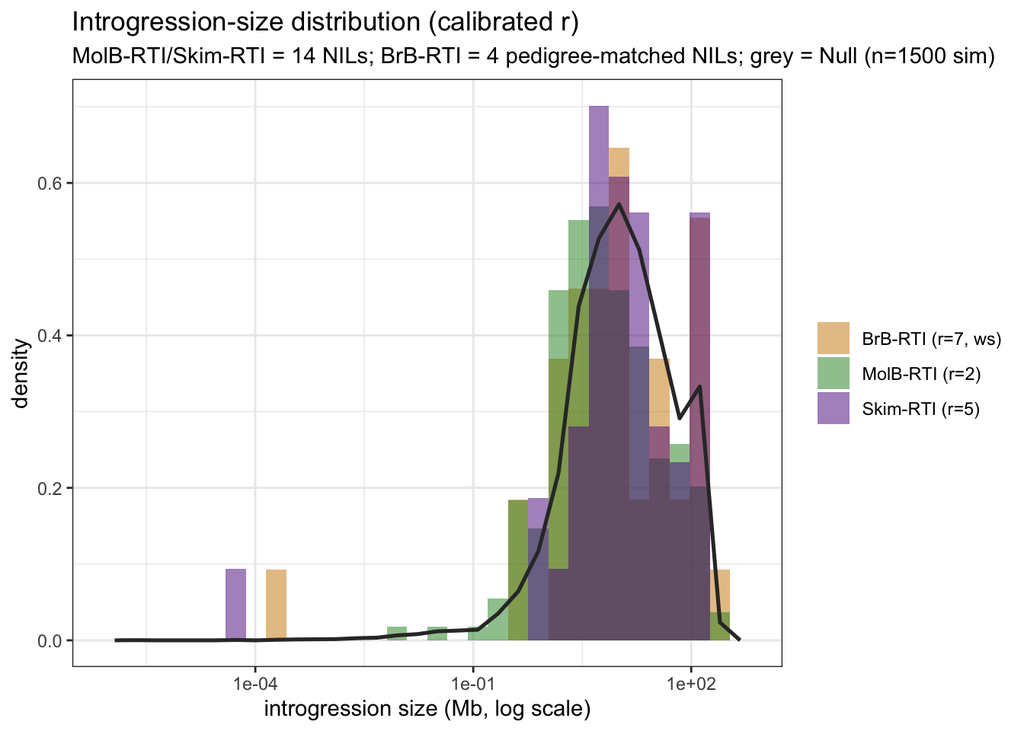

```r
gbts_b <- donor_blocks(mb_s)   %>% mutate(src = "MolB-RTI (r=2)")
skim_b <- donor_blocks(skim_s) %>% mutate(src = "Skim-RTI (r=5)")
brb_b  <- donor_blocks(brb_s)  %>% mutate(src = "BrB-RTI (r=7, ws)")
null_b <- nil_seg %>% transmute(size_mb = mb)
ggplot(bind_rows(gbts_b, skim_b, brb_b), aes(x = size_mb, fill = src)) +
  geom_histogram(aes(y = after_stat(density)), position = "identity", alpha = 0.5, bins = 30) +
  geom_freqpoly(data = null_b, aes(x = size_mb, y = after_stat(density)),
                bins = 30, colour = "grey20", linewidth = 0.9, inherit.aes = FALSE) +
  scale_fill_manual(values = c("MolB-RTI (r=2)" = "forestgreen", "Skim-RTI (r=5)" = "purple4",
                               "BrB-RTI (r=7, ws)" = "orange3")) +
  scale_x_log10() +
  labs(x = "introgression size (Mb, log scale)", y = "density", fill = NULL,
       title = "Introgression-size distribution (calibrated r)",
       subtitle = "MolB-RTI/Skim-RTI = 14 NILs; BrB-RTI = 4 pedigree-matched NILs; grey = Null (n=1500 sim)") +
  theme_bw()
```

## Chromosome painting — 16 MolB lines × 3 source-method tracks

Per NIL: three stacked tracks — **MolB-RTI (r=2)** top, **Skim-RTI (r=5)** middle, **BrB-RTI (r=7, ws)** bottom (method labels at the right). Each row is labelled at the left by its **SNP50K skim coverage λ (×)** over the wrapped **pedigree** (`B73` for the two checks). Palette `REF` gold / `HET` springgreen4 / `ALT` purple4. The BrB-RTI lane is **real** (pedigree-matched, relabelled to the MolB id) for the 4 NILs; **blank** for the 2 B73 checks (putative fill held pending Hannah) and the 10 NILs with no BRB counterpart. Labels in **bold** are `LowQuality` (sample-map QC).

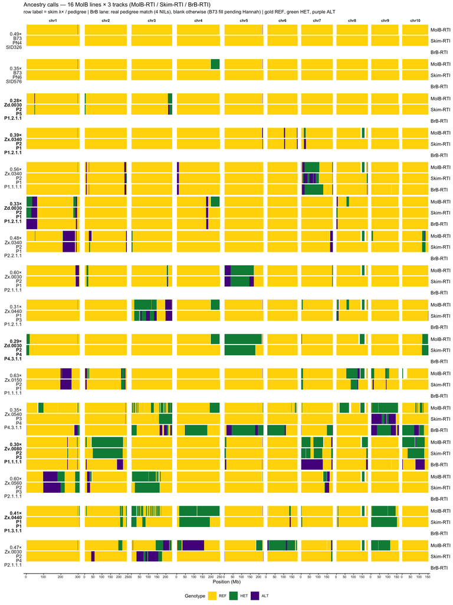

```r
pal <- c(REF = "gold", HET = "springgreen4", ALT = "purple4")
ord <- c(checks, dose %>% filter(!name %in% checks) %>% arrange(molb_r2) %>% pull(name))
lowq <- smap$sample_id[smap$quality == "LowQuality" & !is.na(smap$quality)]

# row label = the .B-dropped PEDIGREE string (NILs) / "B73_<id>" (the 2 checks, kept
# distinct so facets don't collide), wrapped at "_" into multiple lines (ggtext <br>),
# bold for LowQuality — matching the skim_vs_brbseq painting label treatment.
lab_tab <- read_csv(params$corr3, show_col_types = FALSE) %>%
  transmute(name = molb_prefix,
            base = ifelse(type == "NIL", molb_ped, paste0("B73_", molb_prefix)))
name_lab <- function(x) {
  base <- lab_tab$base[match(x, lab_tab$name)]; base[is.na(base)] <- x[is.na(base)]
  ped  <- gsub("_", "<br>", base)
  lam  <- skim_lambda$lambda[match(x, skim_lambda$name)]                 # skim coverage λ
  out  <- ifelse(is.na(lam), ped, sprintf("%.2f×<br>%s", lam, ped))      # λ× on top, pedigree below
  if_else(x %in% lowq, paste0("**", out, "**"), out)
}

paint <- bind_rows(
  mb   %>% transmute(name, chr, start_bp, end_bp, state, method = "MolB-RTI (r=2)"),
  skim %>% filter(name %in% unique(mb$name)) %>%
           transmute(name, chr, start_bp, end_bp, state, method = "Skim-RTI (r=5)"),
  brb  %>% transmute(name, chr, start_bp, end_bp, state, method = "BrB-RTI (r=7, ws)")) %>%
  mutate(state  = factor(state, 0:2, c("REF", "HET", "ALT")),
         chr    = factor(chr, levels = 1:10, labels = paste0("chr", 1:10)),
         name   = factor(name_lab(name), levels = name_lab(ord)),
         method = factor(method, c("MolB-RTI (r=2)","Skim-RTI (r=5)","BrB-RTI (r=7, ws)")),
         ylo = case_when(method == "MolB-RTI (r=2)" ~ 0.69, method == "Skim-RTI (r=5)" ~ 0.35, TRUE ~ 0.00),
         yhi = case_when(method == "MolB-RTI (r=2)" ~ 1.00, method == "Skim-RTI (r=5)" ~ 0.66, TRUE ~ 0.32))

lane_mid <- c(0.16, 0.505, 0.845); lane_lab <- c("BrB-RTI", "Skim-RTI", "MolB-RTI")
ggplot(paint, aes(xmin = start_bp/1e6, xmax = end_bp/1e6, ymin = ylo, ymax = yhi, fill = state)) +
  geom_rect() +
  facet_grid(name ~ chr, scales = "free_x", space = "free_x", switch = "y") +
  scale_fill_manual(values = pal, drop = FALSE) +
  scale_x_continuous(labels = scales::unit_format(unit = "", scale = 1)) +
  scale_y_continuous(breaks = lane_mid, labels = lane_lab,
                     expand = expansion(mult = 0.02), position = "right") +
  labs(title = "Ancestry calls — 16 MolB lines × 3 tracks (MolB-RTI / Skim-RTI / BrB-RTI)",
       subtitle = "row label = skim λ× / pedigree | BrB lane: real pedigree match (4 NILs), blank otherwise (B73 fill pending Hannah) | gold REF, green HET, purple ALT",
       x = "Position (Mb)", fill = "Genotype") +
  ggpubr::theme_classic2(base_size = 9) +
  theme(legend.position = "bottom",
        strip.background = element_blank(),
        strip.text.x = element_text(face = "bold"),
        strip.text.y.left = ggtext::element_markdown(angle = 0, hjust = 1, size = 9, lineheight = 0.85),
        panel.spacing.x = unit(0.05, "lines"), panel.spacing.y = unit(0.05, "lines"),
        axis.text.y.right = element_text(size = 9), axis.ticks.y = element_blank(),
        axis.title.y = element_blank(), axis.line.y = element_blank(),
        axis.text.x = element_text(size = 6))
```

## Jaccard agreement vs Skim-BIN calls

Per-sample Jaccard of donor-present markers (state ∈ {het, donor}) on the common grid, each method vs **Skim-BIN** (1 Mb-bin GMM-HMM on the same skim reads). Restricted to the samples scored by all three RTIGER methods (the real pedigree-matched NILs).

```r
donor_set <- function(df, s) { st <- state_at(df, s); which(!is.na(st) & st > 0) }
jaccard_vs_gmm <- function(df, s) {
  if (!s %in% df$name || !s %in% gmm$name) return(NA_real_)
  a <- donor_set(df, s); b <- donor_set(gmm, s)
  u <- length(union(a, b)); if (u == 0) return(NA_real_)
  length(intersect(a, b)) / u
}
jac <- tibble(sample = brb_samples) %>%
  mutate(`MolB-RTI` = map_dbl(sample, ~ jaccard_vs_gmm(mb,       .x)),
         `Skim-RTI` = map_dbl(sample, ~ jaccard_vs_gmm(skim,     .x)),
         `BrB-RTI`  = map_dbl(sample, ~ jaccard_vs_gmm(brb_nils, .x))) %>%
  filter(if_all(c(`MolB-RTI`, `Skim-RTI`, `BrB-RTI`), ~ !is.na(.x)))
jac %>% knitr::kable(digits = 3,
  caption = "Jaccard agreement of donor-present markers vs Skim-BIN (per NIL × method).")
```

Jaccard agreement of donor-present markers vs Skim-BIN (per NIL × method).

| sample | MolB-RTI | Skim-RTI | BrB-RTI |
| --- | --- | --- | --- |
| PN12_SID1101 | 0.822 | 0.850 | 0.595 |
| PN4_SID290 | 0.821 | 0.776 | 0.773 |
| PN6_SID492 | 0.611 | 0.688 | 0.253 |
| PN6_SID524 | 0.948 | 0.969 | 0.773 |

## Findings

- **Per-platform calibrated rigidity.** MolB-RTI r=2, Skim-RTI r=5, **BrB-RTI r=7** (wideseq-filtered, KS-calibrated). On the full BRB SNP set the noisy 3′ markers forced r=109; restricting to the 21,665 wideseq-informative positions drops it to r=7 — the Skim-RTI regime (D=0.103 < the old 0.112).
- **BRB↔︎MolB is a pedigree join, not a prefix join.** BRB-seq has its own `PN#_SID#` id space, so only **4 of 14** MolB NILs have a real BRB counterpart. The old prefix-join compared unrelated samples — corrected here.
- **MolB-RTI resolves more het / finer structure** than the ~0.4× skim, the expected direction; disagreements concentrate at MolB-het / Skim-recurrent sites.
- **B73 checks read ≈ 0 donor** on MolB-RTI/Skim-RTI — polarity and the recurrent control pass. Their BrB lane is left **blank**: B73 is monomorphic and the BRB checks have no pedigree, so a cross-experiment B73 id can’t be confirmed without a physical-sample key (pending Hannah).
- **BrB-RTI stays a coarse qualitative layer** even wideseq-filtered at r=7 — on the 4 real NILs it recovers only part of the MolB-RTI donor footprint; useful as a sanity layer, not a fine-scale ancestry map. ```